# My Introduction:

### Name: Sunny Kumar Vaishnov

### Student number: S3822295

### Group number 165 (Individual Only)

### Phase 2 report of MATH 2319(Machine Learning)

### Title:- Predictive Modelling on the Dataset.

### Course Coordinator & Course Lecturer: Dr. Vural Aksakalli

# 1. Introduction:

I have the following dataset for the Math2319(Machine Learning) Phase 1 Assignment. The objective of this `House Rent Prediction` dataset is to predict the monthly rent prices of available homes which are based on based on various explanatory variables describing aspects of residential houses.It is sourced from [Kaggle.com](https://www.kaggle.com/rkb0023/houserentpredictiondataset) The dataset comprises of 265190 house records with 22 columns.  
We have already perform some steps on the data such as pre-processing and data visualization in the **Phase 1** part of this course.  
In this Part i.e **Phase 2**, we will perform further evaluations. The steps we are going to perform are listed below.

## 1.2 Overview of Methodology

The first step in our modelling technique is to transform the entire dataset that was already cleansed in Phase I. We changed the data after pre-processing in Phase 1 by encoding categorical descriptive features as numerical and then scaled the descriptive characteristics. Following that, we divided the data into training and test sets in a 70:30 ratio. To be explicit, the 2145 rows of data used during the hyperparameter tuning phase are referred to as the training data. The test data is the 920 rows of data utilised during the performance comparison phase.

We use the sophisticated Random Forest Importance approach inside a pipeline to select the best features before fitting a particular classifier on the training data. After encoding category features, we consider 10, 20, and the entire set of features (with 31 features). We undertake 5-fold stratified cross-validation to fine-tune hyperparameters of each classifier using the area under the curve (AUC) as the performance metric, using feature selection and hyperparameter search within a single pipeline. We use parallel processing with "-2" cores to create each model.

Because the target feature has a higher number of rent prices below $1500 per month (an unbalanced target class issue), stratification is necessary to ensure that each validation set has the same number of classes as the original dataset. During the search, we additionally look at the sensitivity of each model to its hyperparameters. We "fit" the tuned classifiers on the test data using 10-fold cross-validation in a paired fashion after identifying the three tuned classifiers (with the optimal hyperparameter values), and we do paired t-tests to evaluate if any performance difference is statistically significant. We also compare the classifiers on the test data in terms of their recall scores and confusion matrices.

We consider the following (binary) classifiers to predict the target feature:  
K-Nearest Neighbors (KNN),  
Decision trees (DT), and  
Naive Bayes (NB).

# 2. Data-preprocessing:

To begin with data pre-processing we have to import certain functions in python. The Function imported are `warnings` which is used to ignore the warnings while pre-processing.  
Next, we use `pandas` and `numpy` which are very helpful in cleaning the dataset.  
We also have to import `Kneighborsregressor` and other functions as well to perform our analysis.

## 2.1 Importing Data and Functions

```python
import warnings
warnings.filterwarnings('ignore')
import pandas as pd
import numpy as np
from sklearn.neighbors import KNeighborsRegressor
```

Next, we will import the pre-processed dataset on which we have already worked on in the Phase 1 Assignment and named it as `Finaldf` and `head()` is used to display few initial observations of the dataset.

```python
Finaldf = pd.read_csv ('D:\Rmit\Semester 3\Machine Learning\Assignments\Assignment 3\Finaldf.csv')
Finaldf.head()
```

|  | rent price | type | sqfeet | beds | baths | cats allowed | dogs allowed | smoking allowed | wheelchair access | electric vehicle charge | furnished | Laundry options | parking options |
| --- | --- | --- | --- | --- | --- | --- | --- | --- | --- | --- | --- | --- | --- |
| 0 | 1070 | apartment | 1336 | 3 | 2.0 | 1 | 1 | 1 | 0 | 0 | 0 | w/d in unit | off-street parking |
| 1 | 1300 | apartment | 760 | 1 | 1.0 | 1 | 1 | 0 | 1 | 0 | 0 | laundry on site | carport |
| 2 | 995 | apartment | 740 | 2 | 1.0 | 1 | 1 | 1 | 0 | 0 | 0 | laundry on site | off-street parking |
| 3 | 785 | apartment | 1100 | 2 | 2.0 | 1 | 1 | 1 | 0 | 0 | 0 | laundry on site | off-street parking |
| 4 | 650 | apartment | 750 | 1 | 1.0 | 0 | 0 | 1 | 0 | 0 | 0 | laundry in bldg | detached garage |

Below we are highlighting the unique values that are present in our **categorical variables** in the dataset.

```python
categoricalColumns = Finaldf.columns[Finaldf.dtypes==object].tolist()

for col in categoricalColumns:
    print('Unique values for ' + col)
    print(Finaldf[col].unique())
    print('')
```

```
Unique values for type
['apartment' 'condo' 'house' 'manufactured' 'duplex' 'townhouse' 'loft'
 'in-law' 'cottage/cabin' 'flat']

Unique values for Laundry options
['w/d in unit' 'laundry on site' 'laundry in bldg' 'w/d hookups'
 'no laundry on site']

Unique values for parking options
['off-street parking' 'carport' 'detached garage' 'street parking'
 'attached garage' 'no parking' 'valet parking']
```

## 2.2 One-hot Encoding

Below, we are performing the one-hot encoding on the categorical variables

```python
categorical_cols = ['Laundry options','parking options','type']
```

```python
# use one-hot-encoding for categorical features with >2 levels
Finaldf = pd.get_dummies(Finaldf)
Finaldf.columns
```

```
Index(['rent price', 'sqfeet', 'beds', 'baths', 'cats allowed', 'dogs allowed',
       'smoking allowed', 'wheelchair access', 'electric vehicle charge',
       'furnished', 'type_apartment', 'type_condo', 'type_cottage/cabin',
       'type_duplex', 'type_flat', 'type_house', 'type_in-law', 'type_loft',
       'type_manufactured', 'type_townhouse',
       'Laundry options_laundry in bldg', 'Laundry options_laundry on site',
       'Laundry options_no laundry on site', 'Laundry options_w/d hookups',
       'Laundry options_w/d in unit', 'parking options_attached garage',
       'parking options_carport', 'parking options_detached garage',
       'parking options_no parking', 'parking options_off-street parking',
       'parking options_street parking', 'parking options_valet parking'],
      dtype='object')
```

Below, we are displaying the `Finaldf` after the **One-hot encoding**.

```python
Finaldf.head()
```

|  | rent price | sqfeet | beds | baths | cats allowed | dogs allowed | smoking allowed | wheelchair access | electric vehicle charge | furnished | ... | Laundry options_no laundry on site | Laundry options_w/d hookups | Laundry options_w/d in unit | parking options_attached garage | parking options_carport | parking options_detached garage | parking options_no parking | parking options_off-street parking | parking options_street parking | parking options_valet parking |
| --- | --- | --- | --- | --- | --- | --- | --- | --- | --- | --- | --- | --- | --- | --- | --- | --- | --- | --- | --- | --- | --- |
| 0 | 1070 | 1336 | 3 | 2.0 | 1 | 1 | 1 | 0 | 0 | 0 | ... | 0 | 0 | 1 | 0 | 0 | 0 | 0 | 1 | 0 | 0 |
| 1 | 1300 | 760 | 1 | 1.0 | 1 | 1 | 0 | 1 | 0 | 0 | ... | 0 | 0 | 0 | 0 | 1 | 0 | 0 | 0 | 0 | 0 |
| 2 | 995 | 740 | 2 | 1.0 | 1 | 1 | 1 | 0 | 0 | 0 | ... | 0 | 0 | 0 | 0 | 0 | 0 | 0 | 1 | 0 | 0 |
| 3 | 785 | 1100 | 2 | 2.0 | 1 | 1 | 1 | 0 | 0 | 0 | ... | 0 | 0 | 0 | 0 | 0 | 0 | 0 | 1 | 0 | 0 |
| 4 | 650 | 750 | 1 | 1.0 | 0 | 0 | 1 | 0 | 0 | 0 | ... | 0 | 0 | 0 | 0 | 0 | 1 | 0 | 0 | 0 | 0 |

5 rows × 32 columns

Our target feature- `rent price` has various numeric values and we have to convert into binary variables of 0 and 1. our variable has different rent prices from 0-15667 per month. So,we have bifurcated them.

```python
Finaldf.loc[(Finaldf["rent price"] >= 1) & (Finaldf["rent price"] <= 1500), "rent price"] = 0
Finaldf.loc[(Finaldf["rent price"] >= 1501) & (Finaldf["rent price"] <= 16000), "rent price"] = 1
Finaldf.head()
```

|  | rent price | sqfeet | beds | baths | cats allowed | dogs allowed | smoking allowed | wheelchair access | electric vehicle charge | furnished | ... | Laundry options_no laundry on site | Laundry options_w/d hookups | Laundry options_w/d in unit | parking options_attached garage | parking options_carport | parking options_detached garage | parking options_no parking | parking options_off-street parking | parking options_street parking | parking options_valet parking |
| --- | --- | --- | --- | --- | --- | --- | --- | --- | --- | --- | --- | --- | --- | --- | --- | --- | --- | --- | --- | --- | --- |
| 0 | 0 | 1336 | 3 | 2.0 | 1 | 1 | 1 | 0 | 0 | 0 | ... | 0 | 0 | 1 | 0 | 0 | 0 | 0 | 1 | 0 | 0 |
| 1 | 0 | 760 | 1 | 1.0 | 1 | 1 | 0 | 1 | 0 | 0 | ... | 0 | 0 | 0 | 0 | 1 | 0 | 0 | 0 | 0 | 0 |
| 2 | 0 | 740 | 2 | 1.0 | 1 | 1 | 1 | 0 | 0 | 0 | ... | 0 | 0 | 0 | 0 | 0 | 0 | 0 | 1 | 0 | 0 |
| 3 | 0 | 1100 | 2 | 2.0 | 1 | 1 | 1 | 0 | 0 | 0 | ... | 0 | 0 | 0 | 0 | 0 | 0 | 0 | 1 | 0 | 0 |
| 4 | 0 | 750 | 1 | 1.0 | 0 | 0 | 1 | 0 | 0 | 0 | ... | 0 | 0 | 0 | 0 | 0 | 1 | 0 | 0 | 0 | 0 |

5 rows × 32 columns

Here we are assigning our target variable into a different column and name it as `target`.

```python
x = Finaldf.drop(columns='rent price')
target = Finaldf['rent price']
target = pd.DataFrame(target)
target.head()
```

|  | rent price |
| --- | --- |
| 0 | 0 |
| 1 | 0 |
| 2 | 0 |
| 3 | 0 |
| 4 | 0 |

After separating the target column from the dataset, we create a new column named `data` which contains all of the rest variables.

```python
Data = x
Data.head()
```

|  | sqfeet | beds | baths | cats allowed | dogs allowed | smoking allowed | wheelchair access | electric vehicle charge | furnished | type_apartment | ... | Laundry options_no laundry on site | Laundry options_w/d hookups | Laundry options_w/d in unit | parking options_attached garage | parking options_carport | parking options_detached garage | parking options_no parking | parking options_off-street parking | parking options_street parking | parking options_valet parking |
| --- | --- | --- | --- | --- | --- | --- | --- | --- | --- | --- | --- | --- | --- | --- | --- | --- | --- | --- | --- | --- | --- |
| 0 | 1336 | 3 | 2.0 | 1 | 1 | 1 | 0 | 0 | 0 | 1 | ... | 0 | 0 | 1 | 0 | 0 | 0 | 0 | 1 | 0 | 0 |
| 1 | 760 | 1 | 1.0 | 1 | 1 | 0 | 1 | 0 | 0 | 1 | ... | 0 | 0 | 0 | 0 | 1 | 0 | 0 | 0 | 0 | 0 |
| 2 | 740 | 2 | 1.0 | 1 | 1 | 1 | 0 | 0 | 0 | 1 | ... | 0 | 0 | 0 | 0 | 0 | 0 | 0 | 1 | 0 | 0 |
| 3 | 1100 | 2 | 2.0 | 1 | 1 | 1 | 0 | 0 | 0 | 1 | ... | 0 | 0 | 0 | 0 | 0 | 0 | 0 | 1 | 0 | 0 |
| 4 | 750 | 1 | 1.0 | 0 | 0 | 1 | 0 | 0 | 0 | 1 | ... | 0 | 0 | 0 | 0 | 0 | 1 | 0 | 0 | 0 | 0 |

5 rows × 31 columns

## 2.3 Scaling

Now, we will Scale our unscaled dataset and assign it to a new df named as `New_df`.

```python
from sklearn import preprocessing

Data_df = Data.copy()

Data_scaler = preprocessing.MinMaxScaler()
Data_scaler.fit(Data)
Data = Data_scaler.fit_transform(Data)

New_df= pd.DataFrame(Data, columns=Data_df.columns)

New_df.head(10)
```

|  | sqfeet | beds | baths | cats allowed | dogs allowed | smoking allowed | wheelchair access | electric vehicle charge | furnished | type_apartment | ... | Laundry options_no laundry on site | Laundry options_w/d hookups | Laundry options_w/d in unit | parking options_attached garage | parking options_carport | parking options_detached garage | parking options_no parking | parking options_off-street parking | parking options_street parking | parking options_valet parking |
| --- | --- | --- | --- | --- | --- | --- | --- | --- | --- | --- | --- | --- | --- | --- | --- | --- | --- | --- | --- | --- | --- |
| 0 | 0.102228 | 0.428571 | 0.363636 | 1.0 | 1.0 | 1.0 | 0.0 | 0.0 | 0.0 | 1.0 | ... | 0.0 | 0.0 | 1.0 | 0.0 | 0.0 | 0.0 | 0.0 | 1.0 | 0.0 | 0.0 |
| 1 | 0.058121 | 0.142857 | 0.181818 | 1.0 | 1.0 | 0.0 | 1.0 | 0.0 | 0.0 | 1.0 | ... | 0.0 | 0.0 | 0.0 | 0.0 | 1.0 | 0.0 | 0.0 | 0.0 | 0.0 | 0.0 |
| 2 | 0.056589 | 0.285714 | 0.181818 | 1.0 | 1.0 | 1.0 | 0.0 | 0.0 | 0.0 | 1.0 | ... | 0.0 | 0.0 | 0.0 | 0.0 | 0.0 | 0.0 | 0.0 | 1.0 | 0.0 | 0.0 |
| 3 | 0.084157 | 0.285714 | 0.363636 | 1.0 | 1.0 | 1.0 | 0.0 | 0.0 | 0.0 | 1.0 | ... | 0.0 | 0.0 | 0.0 | 0.0 | 0.0 | 0.0 | 0.0 | 1.0 | 0.0 | 0.0 |
| 4 | 0.057355 | 0.142857 | 0.181818 | 0.0 | 0.0 | 1.0 | 0.0 | 0.0 | 0.0 | 1.0 | ... | 0.0 | 0.0 | 0.0 | 0.0 | 0.0 | 1.0 | 0.0 | 0.0 | 0.0 | 0.0 |
| 5 | 0.051612 | 0.285714 | 0.181818 | 1.0 | 1.0 | 0.0 | 0.0 | 0.0 | 0.0 | 1.0 | ... | 0.0 | 0.0 | 0.0 | 0.0 | 0.0 | 0.0 | 0.0 | 0.0 | 1.0 | 0.0 |
| 6 | 0.067310 | 0.142857 | 0.181818 | 1.0 | 1.0 | 0.0 | 0.0 | 0.0 | 0.0 | 0.0 | ... | 0.0 | 0.0 | 1.0 | 1.0 | 0.0 | 0.0 | 0.0 | 0.0 | 0.0 | 0.0 |
| 7 | 0.087985 | 0.285714 | 0.181818 | 0.0 | 0.0 | 1.0 | 0.0 | 0.0 | 0.0 | 1.0 | ... | 0.0 | 0.0 | 0.0 | 0.0 | 0.0 | 0.0 | 0.0 | 0.0 | 1.0 | 0.0 |
| 8 | 0.078567 | 0.285714 | 0.181818 | 0.0 | 0.0 | 1.0 | 0.0 | 0.0 | 0.0 | 0.0 | ... | 0.0 | 0.0 | 1.0 | 0.0 | 0.0 | 0.0 | 0.0 | 1.0 | 0.0 | 0.0 |
| 9 | 0.137759 | 0.428571 | 0.363636 | 1.0 | 1.0 | 1.0 | 0.0 | 0.0 | 1.0 | 0.0 | ... | 0.0 | 0.0 | 1.0 | 0.0 | 0.0 | 1.0 | 0.0 | 0.0 | 0.0 | 0.0 |

10 rows × 31 columns

## 2.4 Train-Test Splitting

Here, we are using `Scikit-Learn` Functions to split our dataset into the ratio of 70:30.  
We have also convert `Pandas` into `Numpy` using `values` attribute because if we didn't convert this then we can get some errors while fitting the model. So, it feasible if we perfrom this step before moving forward.We have named our splitted data as `D_train`,`D_Test`,`t_train` and `t_test`.  
We have also displayed the shape of `D_train` and `D_test` just to cross check that the data has been splitted into the ratio of 70:30.

```python
from sklearn.model_selection import train_test_split
Data_numpy = New_df.values
D_train, D_test, t_train, t_test = train_test_split(Data_numpy,
                                                    target.values,
                                                    test_size=0.3,
                                                    random_state=999,stratify
                                                = target)
print(D_train.shape)
print(D_test.shape)
```

```
(2145, 31)
(920, 31)
```

# 3. Predictive Modelling

In this step,we will be performing three major steps:

1. Feature Selection
2. Model Fitting & Tuning
3. Model Comparison

## 3.1 Feature Selection

Now, we will select the best Features of our dataset. Here, we will use **Random Forest Importance(RFI)** and select Top 10 features. We select best features as it comes in handy while performing Hyperparameter tuning.We will include RFI as part of the pipeline and we will search over 10, 20, and the full set of 31 features to determine which number of features works best with each classifier.

```python
from sklearn.ensemble import RandomForestClassifier

num_features = 10
model_rfi = RandomForestClassifier(n_estimators=100)
model_rfi.fit(New_df, target)
fs_indices_rfi = np.argsort(model_rfi.feature_importances_)[::-1][0:num_features]

best_features_rfi = New_df.columns[fs_indices_rfi].values
best_features_rfi
```

```
array(['sqfeet', 'baths', 'beds', 'parking options_attached garage',
       'Laundry options_w/d in unit', 'smoking allowed',
       'parking options_off-street parking', 'cats allowed',
       'dogs allowed', 'wheelchair access'], dtype=object)
```

```python
feature_importances_rfi = model_rfi.feature_importances_[fs_indices_rfi]
feature_importances_rfi.round(3)
```

```
array([0.466, 0.066, 0.064, 0.044, 0.04 , 0.038, 0.034, 0.024, 0.023,
       0.021])
```

Above listed features are top 10 variables in the dataset.  
Now, we will create a visualization of the top 10 features that are present in the dataset.

```python
import matplotlib.pyplot as plt
%matplotlib inline
%config InlineBackend.figure_format = 'retina'
plt.style.use("ggplot")

def plot_imp(best_features, scores, method_name):
    plt.barh(best_features, scores)
    plt.title(method_name + ' Feature Importances')
    plt.xlabel("Importance")
    plt.ylabel("Features")
    plt.show()
```

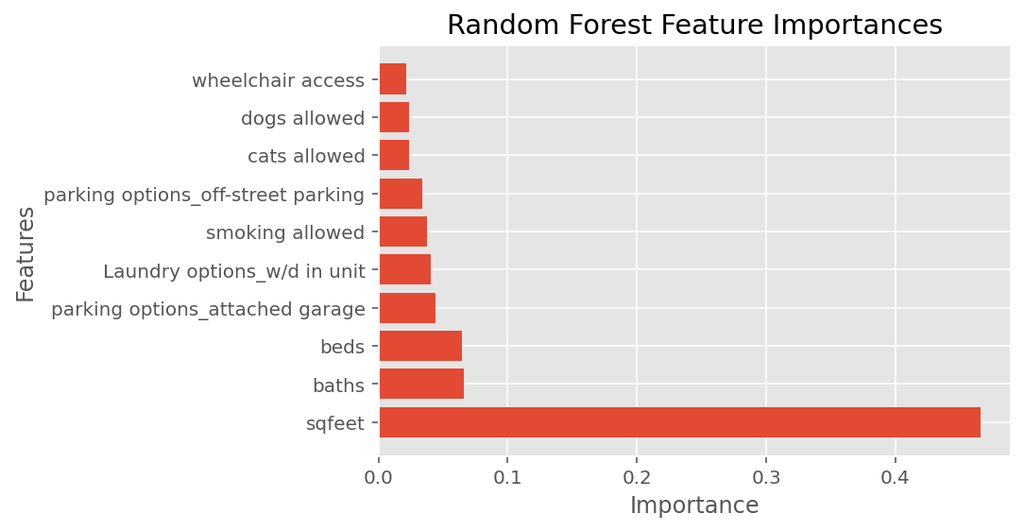

```python
plot_imp(best_features_rfi, feature_importances_rfi, 'Random Forest')
```

As we can see that `sqfeet` variable is the best feature available in the dataset and `baths` following it as well as others listed.

## 3.2 Model Fitting and Tuning

Now, we will fit and tune our dataset using various algorithms.We will perform following steps for each algorithm.

1. Fit the algorithm
2. Find the best Paramaters
3. Find the best score
4. Check for other combinations.
5. Visualize the Model.

We will perform these steps for three algorithms:

1. K-Nearest Neighbors(KNN)
2. (Gaussian) Naive Bayes (NB)
3. Decision Trees (DT)

We have already bifurcated our dataset into 70:30 ratio above. Therefore, we will use 2145 rows for training and remaining 920 rows for testing. For each model, we will use 5-fold stratified cross-validation evaluation method (without any repetitions for shorter run times) for hyperparameter tuning.

```python
from sklearn.model_selection import StratifiedKFold, GridSearchCV

cv_method = StratifiedKFold(n_splits=5, random_state=999)
```

### 3.2.1. K-Nearest Neighbors(KNN)

Here, we will use `Pipeline` to stack feature selection and grid search for KNN hyperparameter tuning via cross-validation. We will use the same Pipeline methodology for NB and DT. The KNN hyperparameters are as follows:

- number of neighbors (n_neighbors) and
- the distance metric p

For feature selection, we use the powerful Random Forest Importance (RFI) method with 100 estimators. To make RFI feature selection as part of the pipeline, we have performed below step. For this reason, we define the custom RFIFeatureSelector() class below to pass in RFI as a **step** to the pipeline

We have imported `BaseEstimator` and `TransformerMixin` to perform the steps.

```python
from sklearn.base import BaseEstimator, TransformerMixin
class RFIFeatureSelector(BaseEstimator, TransformerMixin):

    def __init__(self, n_features_=10):
        self.n_features_ = n_features_
        self.fs_indices_ = None

# Now, we will over ride the fit function and then the Transform function as well.

   # override the fit function
    def fit(self, X, y):
        from sklearn.ensemble import RandomForestClassifier
        from numpy import argsort
        model_rfi = RandomForestClassifier(n_estimators=100)
        model_rfi.fit(X, y)
        self.fs_indices_ = argsort(model_rfi.feature_importances_)[::-1][0:self.n_features_]
        return self

    # override the transform function
    def transform(self, X, y=None):
        return X[:, self.fs_indices_]
```

```python
from sklearn.pipeline import Pipeline
from sklearn.neighbors import KNeighborsClassifier

pipe_KNN = Pipeline(steps=[('rfi_fs', RFIFeatureSelector()),
                           ('knn', KNeighborsClassifier())])

params_pipe_KNN = {'rfi_fs__n_features_': [10, 20, Data.shape[1]],
                   'knn__n_neighbors': [1, 5, 10, 15, 20],
                   'knn__p': [1, 2]}

gs_pipe_KNN = GridSearchCV(estimator=pipe_KNN,
                           param_grid=params_pipe_KNN,
                           cv=cv_method,
                           refit=True,
                           n_jobs=-2,
                           scoring='roc_auc',
                           verbose=1)
```

```python
gs_pipe_KNN.fit(D_train, t_train);
```

```
Fitting 5 folds for each of 30 candidates, totalling 150 fits
```

```
[Parallel(n_jobs=-2)]: Using backend LokyBackend with 3 concurrent workers.
[Parallel(n_jobs=-2)]: Done  44 tasks      | elapsed:   14.7s
[Parallel(n_jobs=-2)]: Done 150 out of 150 | elapsed:   41.7s finished
```

```python
gs_pipe_KNN.best_params_
```

```
{'knn__n_neighbors': 20, 'knn__p': 2, 'rfi_fs__n_features_': 20}
```

```python
gs_pipe_KNN.best_score_.round(3)
```

```
0.773
```

By performing the steps, we can get our optimal KNN Model and it has a mean AUC of 0.772. We got our best performing KNN with selected 20 features, 20 nearest neighbours and p=2, which is Euclidean's Distance.

We got the best values but still we will like to see some combinations as well just to observe that is the difference is significant or not. For that, we have to perform following steps.

```python
def get_search_results(gs):

    def model_result(scores, params):
        scores = {'mean_score': np.mean(scores),
             'std_score': np.std(scores),
             'min_score': np.min(scores),
             'max_score': np.max(scores)}
        return pd.Series({**params,**scores})

    models = []
    scores = []

    for i in range(gs.n_splits_):
        key = f"split{i}_test_score"
        r = gs.cv_results_[key]
        scores.append(r.reshape(-1,1))

    all_scores = np.hstack(scores)
    for p, s in zip(gs.cv_results_['params'], all_scores):
        models.append((model_result(s, p)))

    pipe_results = pd.concat(models, axis=1).T.sort_values(['mean_score'], ascending=False)

    columns_first = ['mean_score', 'std_score', 'max_score', 'min_score']
    columns = columns_first + [c for c in pipe_results.columns if c not in columns_first]

    return pipe_results[columns]
```

```python
results_KNN = get_search_results(gs_pipe_KNN)
results_KNN.head()
```

|  | mean_score | std_score | max_score | min_score | knn__n_neighbors | knn__p | rfi_fs__n_features_ |
| --- | --- | --- | --- | --- | --- | --- | --- |
| 28 | 0.772737 | 0.040372 | 0.841268 | 0.727666 | 20.0 | 2.0 | 20.0 |
| 25 | 0.771364 | 0.041229 | 0.841044 | 0.723642 | 20.0 | 1.0 | 20.0 |
| 22 | 0.770388 | 0.043621 | 0.844321 | 0.720609 | 15.0 | 2.0 | 20.0 |
| 29 | 0.768871 | 0.040659 | 0.829436 | 0.712155 | 20.0 | 2.0 | 31.0 |
| 19 | 0.768764 | 0.043149 | 0.840428 | 0.719587 | 15.0 | 1.0 | 20.0 |

From the above table, we can observe that the difference between hyperparameter combinations when conditioned on the number of selected features is not that much.

Now let's visualize the results on a plot.

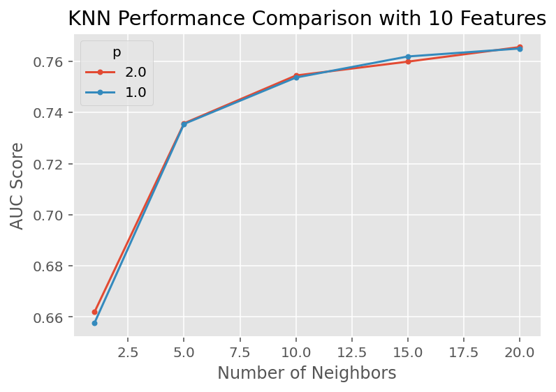

```python
results_KNN_10_features = results_KNN[results_KNN['rfi_fs__n_features_'] == 10.0]

for i in results_KNN_10_features['knn__p'].unique():
    temp = results_KNN_10_features[results_KNN_10_features['knn__p'] == i]
    plt.plot(temp['knn__n_neighbors'], temp['mean_score'], marker = '.', label = i)

plt.legend(title = "p")
plt.xlabel('Number of Neighbors')
plt.ylabel("AUC Score")
plt.title("KNN Performance Comparison with 10 Features")
plt.show()
```

### 3.2.2 (Gaussian) Naive Bayes (NB)

The next algorithm we fit on our dataset is **Gaussian Naive Bayes model**. As we don't have much information about our dataset, we will be using `var_smoothing`. By default, the `var_smoothing` parameter's value is **$10-^9$** . We conduct the grid search in the `logspace` (over the powers of 10) sourced from `NumPy`. We start with 10 and end with **$10−^3$'** with 200 different values, but we perform a random search over only 20 different values (for shorter run times). Since NB requires each descriptive feature to follow a Gaussian distribution, we first perform a power transformation on the input data before model fitting.

```python
from sklearn.preprocessing import PowerTransformer
D_train_transformed = PowerTransformer().fit_transform(D_train)

from sklearn.naive_bayes import GaussianNB
from sklearn.model_selection import RandomizedSearchCV

pipe_NB = Pipeline([('rfi_fs', RFIFeatureSelector()),
                     ('nb', GaussianNB())])

params_pipe_NB = {'rfi_fs__n_features_': [10, 20, Data.shape[1]],
                  'nb__var_smoothing': np.logspace(1,-3, num=200)}

n_iter_search = 20
gs_pipe_NB = RandomizedSearchCV(estimator=pipe_NB,
                          param_distributions=params_pipe_NB,
                          cv=cv_method,
                          refit=True,
                          n_jobs=-2,
                          scoring='roc_auc',
                          n_iter=n_iter_search,
                          verbose=1)

gs_pipe_NB.fit(D_train_transformed, t_train);
```

```
Fitting 5 folds for each of 20 candidates, totalling 100 fits
```

```
[Parallel(n_jobs=-2)]: Using backend LokyBackend with 3 concurrent workers.
[Parallel(n_jobs=-2)]: Done  44 tasks      | elapsed:    8.7s
[Parallel(n_jobs=-2)]: Done 100 out of 100 | elapsed:   20.8s finished
```

```python
gs_pipe_NB.best_params_
```

```
{'rfi_fs__n_features_': 10, 'nb__var_smoothing': 0.4713753134116724}
```

```python
gs_pipe_NB.best_score_.round(3)
```

```
0.766
```

```python
results_NB = get_search_results(gs_pipe_NB)
results_NB.head()
```

|  | mean_score | std_score | max_score | min_score | rfi_fs__n_features_ | nb__var_smoothing |
| --- | --- | --- | --- | --- | --- | --- |
| 0 | 0.766392 | 0.042550 | 0.823863 | 0.694820 | 10.0 | 0.471375 |
| 16 | 0.766035 | 0.043277 | 0.824227 | 0.693762 | 10.0 | 0.102341 |
| 10 | 0.766025 | 0.041309 | 0.824031 | 0.697271 | 10.0 | 2.072922 |
| 13 | 0.765878 | 0.043306 | 0.824031 | 0.693706 | 10.0 | 0.046595 |
| 14 | 0.764967 | 0.040948 | 0.822967 | 0.696853 | 10.0 | 4.150405 |

From the above table, we can observe that the difference between hyperparameter combinations when conditioned on the number of selected features is not that much.

Now let's visualize the results on a plot.

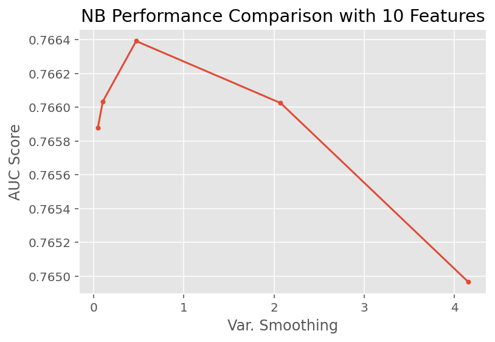

```python
results_NB_10_features = results_NB[results_NB['rfi_fs__n_features_'] == 10.0].sort_values('nb__var_smoothing')

plt.plot(results_NB_10_features['nb__var_smoothing'], results_NB_10_features['mean_score'], marker = '.', label = i)
plt.xlabel('Var. Smoothing')
plt.ylabel("AUC Score")
plt.title("NB Performance Comparison with 10 Features")
plt.show()
```

At this point, we cannot conclude NB outperforms KNN. For this conclusion, we will have to perform a paired t-test on the test data as discussed further below.

### 3.2.3 Decision Trees (DT)

Now, we will build a DT using gini index to maximize information gain. We aim to determine the optimal combinations of maximum depth (`max_depth`) and minimum sample split (`min_samples_split`).

```python
from sklearn.tree import DecisionTreeClassifier

pipe_DT = Pipeline([('rfi_fs', RFIFeatureSelector()),
                    ('dt', DecisionTreeClassifier(criterion='gini', random_state=111))])

params_pipe_DT = {'rfi_fs__n_features_': [10, 20, Data.shape[1]],
                  'dt__max_depth': [3, 4, 5],
                  'dt__min_samples_split': [2, 5]}

gs_pipe_DT = GridSearchCV(estimator=pipe_DT,
                          param_grid=params_pipe_DT,
                          cv=cv_method,
                          refit=True,
                          n_jobs=-2,
                          scoring='roc_auc',
                          verbose=1)

gs_pipe_DT.fit(D_train, t_train);
```

```
Fitting 5 folds for each of 18 candidates, totalling 90 fits
```

```
[Parallel(n_jobs=-2)]: Using backend LokyBackend with 3 concurrent workers.
[Parallel(n_jobs=-2)]: Done  44 tasks      | elapsed:   10.8s
[Parallel(n_jobs=-2)]: Done  90 out of  90 | elapsed:   25.5s finished
```

```python
gs_pipe_DT.best_params_
```

```
{'dt__max_depth': 4, 'dt__min_samples_split': 2, 'rfi_fs__n_features_': 10}
```

```python
gs_pipe_DT.best_score_.round(3)
```

```
0.764
```

From the above, we can say that the best **DT model** has a maximum depth of 4 and minimum split value of 2 samples and the **AUC Score** is 0.764 which is slightly less than both the above models i.e KNN and NB.

Now, we will visualize the model.

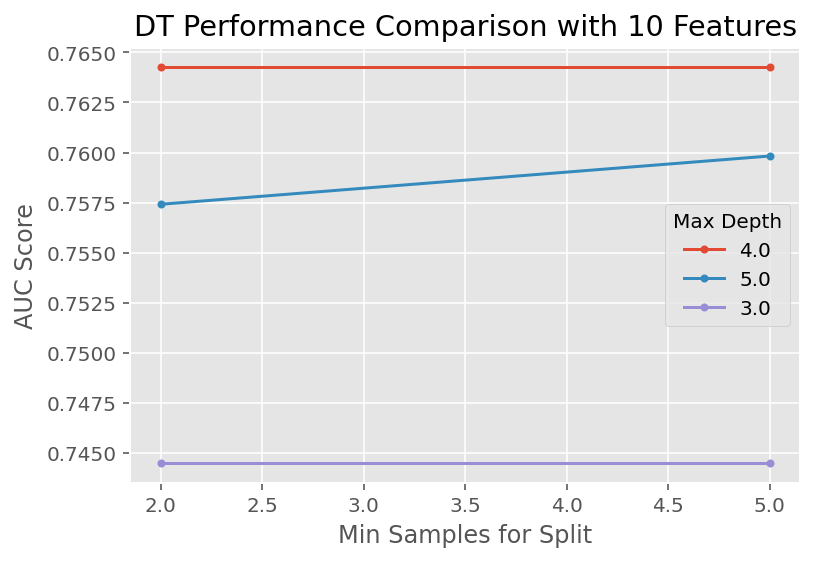

```python
results_DT = get_search_results(gs_pipe_DT)
results_DT_10_features = results_DT[results_DT['rfi_fs__n_features_'] == 10.0]


for i in results_DT_10_features['dt__max_depth'].unique():
    temp = results_DT_10_features[results_DT_10_features['dt__max_depth'] == i]
    plt.plot(temp['dt__min_samples_split'], temp['mean_score'], marker = '.', label = i)

plt.legend(title = "Max Depth")
plt.xlabel('Min Samples for Split')
plt.ylabel("AUC Score")
plt.title("DT Performance Comparison with 10 Features")
plt.show()
```

#### Further Fine Tuning:

```python
params_pipe_DT2 = {'rfi_fs__n_features_': [10],
                  'dt__max_depth': [5, 10, 15],
                  'dt__min_samples_split': [5, 50, 100, 150]}

gs_pipe_DT2 = GridSearchCV(estimator=pipe_DT,
                          param_grid=params_pipe_DT2,
                          cv=cv_method,
                          refit=True,
                          n_jobs=-2,
                          scoring='roc_auc',
                          verbose=1)

gs_pipe_DT2.fit(D_train, t_train);
```

```
Fitting 5 folds for each of 12 candidates, totalling 60 fits
```

```
[Parallel(n_jobs=-2)]: Using backend LokyBackend with 3 concurrent workers.
[Parallel(n_jobs=-2)]: Done  44 tasks      | elapsed:   12.5s
[Parallel(n_jobs=-2)]: Done  60 out of  60 | elapsed:   15.9s finished
```

```python
gs_pipe_DT2.best_params_
```

```
{'dt__max_depth': 10, 'dt__min_samples_split': 150, 'rfi_fs__n_features_': 10}
```

```python
gs_pipe_DT2.best_score_.round(3)
```

```
0.773
```

As we mentioned earlier, that there maybe some chances that we are missing out on better values and we were right. AFter performing above steps, we can see that the results we got are not much difference from above one but still they are slightly better. The new result is better then the previous one as well as it is better then NB model and almost equal to KNN.

```python
results_DT = get_search_results(gs_pipe_DT2)
results_DT.head()
```

|  | mean_score | std_score | max_score | min_score | dt__max_depth | dt__min_samples_split | rfi_fs__n_features_ |
| --- | --- | --- | --- | --- | --- | --- | --- |
| 7 | 0.773166 | 0.041616 | 0.849067 | 0.722793 | 10.0 | 150.0 | 10.0 |
| 11 | 0.772720 | 0.042161 | 0.849067 | 0.720565 | 15.0 | 150.0 | 10.0 |
| 6 | 0.769287 | 0.047650 | 0.847849 | 0.702757 | 10.0 | 100.0 | 10.0 |
| 3 | 0.768298 | 0.036430 | 0.827602 | 0.713311 | 5.0 | 150.0 | 10.0 |
| 10 | 0.767850 | 0.049378 | 0.848129 | 0.697967 | 15.0 | 100.0 | 10.0 |

In the table above, we can see that the cross -validated AUC score difference between the hyper parameter combinations is not really much.

Now, we will visualize the Model.

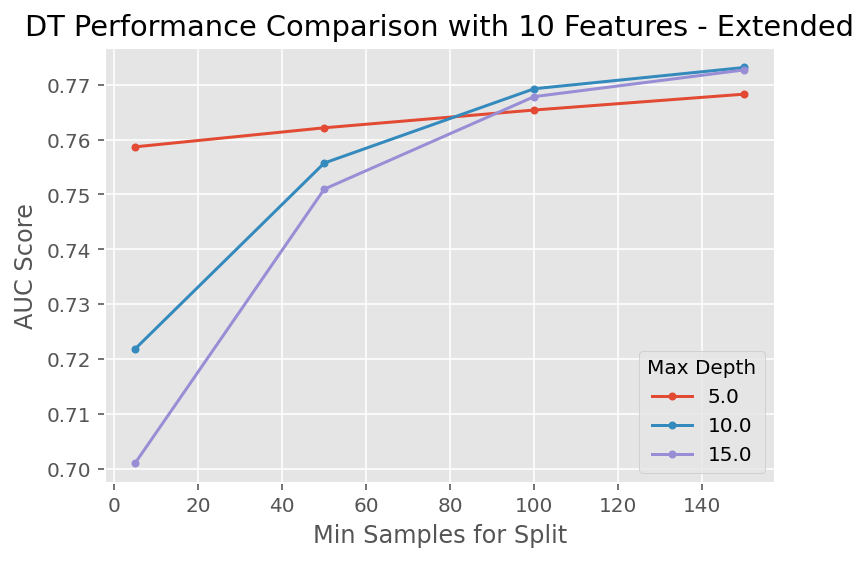

```python
results_DT_10_features = results_DT[results_DT['rfi_fs__n_features_'] == 10.0].sort_values('dt__min_samples_split')


for i in results_DT_10_features['dt__max_depth'].unique():
    temp = results_DT_10_features[results_DT_10_features['dt__max_depth'] == i]
    plt.plot(temp['dt__min_samples_split'], temp['mean_score'], marker = '.', label = i)

plt.legend(title = "Max Depth")
plt.xlabel('Min Samples for Split')
plt.ylabel("AUC Score")
plt.title("DT Performance Comparison with 10 Features - Extended")
plt.show()
```

## 3.3 Model Comparison

In the above steps of hyperparameter tuning phase, we used 2145 rows in our training data within a cross-validation framework and with the help of that we found out the best hyperparameter values for each of the three classifiers. Now we will try to fit each tuned classifier on the remaining 920 rows in the test data in a cross-validated fashion to figure out which (tuned) classifier performs the best. We will also like to perform pair T-test to find out the difference between the performance of two classifiers and if there is any difference whether it is statistically significant or not.

Following are steps we will going to follow:

1. We will perform 10-fold stratified cross-validation on every classifier.
2. We will conduct a paired t-test for the AUC score between the following (tuned) classifier combinations:  
   KNN vs. NB,  
   KNN vs. DT,  
   DT vs. NB.

We will use 10-fold stratified cross-validation evaluation method for hyperparameter tuning and name it as `cv_method_test` and going to use in every step.We are using the fix random state in every step during the cross-validation, it means that all the classifiers were fitted and tested on the same partitions and making our results **paired** in statiscal sense.

```python
from sklearn.model_selection import cross_val_score

cv_method_test = StratifiedKFold(n_splits=10, random_state=111)
```

```python
cv_results_KNN = cross_val_score(estimator=gs_pipe_KNN.best_estimator_,
                                 X=D_test,
                                 y=t_test,
                                 cv=cv_method_test,
                                 n_jobs= -2,
                                 scoring='roc_auc')

cv_results_KNN.mean().round(3)
```

```
0.782
```

```python
Data_sample_test_transformed = PowerTransformer().fit_transform(D_test)

cv_results_NB = cross_val_score(estimator=gs_pipe_NB.best_estimator_,
                                X=Data_sample_test_transformed,
                                y=t_test,
                                cv=cv_method_test,
                                n_jobs=-2,
                                scoring='roc_auc')
cv_results_NB.mean().round(3)
```

```
0.766
```

```python
cv_results_DT = cross_val_score(estimator=gs_pipe_DT2.best_estimator_,
                                X=D_test,
                                y=t_test,
                                cv=cv_method_test,
                                n_jobs=-2,
                                scoring='roc_auc')
cv_results_DT.mean().round(3)
```

```
0.754
```

In the above step, we have same random state which makes the classifier paired. So, we will now use `stats.ttest_rel` function to run the following (paired) t-tests.

The value of paired t-test can be measured in two ways:

1. P- value is lower 0.05, which means that the difference is statistically significant.
2. P- value is higher 0.05, which means that the difference is not statistically significant.

Now, lets run the test and find out the difference is statistically significant or not.

```python
from scipy import stats

print(stats.ttest_rel(cv_results_KNN, cv_results_NB))
print(stats.ttest_rel(cv_results_DT, cv_results_KNN))
print(stats.ttest_rel(cv_results_DT, cv_results_NB))
```

```
Ttest_relResult(statistic=1.1847216030736727, pvalue=0.26646822475509674)
Ttest_relResult(statistic=-2.9717824938264514, pvalue=0.015657047014539845)
Ttest_relResult(statistic=-1.09976889401075, pvalue=0.2999782281140095)
```

We will use the following metrics to evaluate models based on the test set, even though we utilised AUC to tune the algorithm hyperparameters:

- Accuracy
- Precision
- Recall
- F1 Score (the harmonic average of precision and recall)
- Confusion Matrix

These metrics can be computed using `classification_report` from `sklearn.metrics`. The classification reports are shown below.

```python
pred_KNN = gs_pipe_KNN.predict(D_test)
```

```python
Data_test_transformed = PowerTransformer().fit_transform(D_test)
pred_NB = gs_pipe_NB.predict(Data_test_transformed)
```

```python
pred_DT = gs_pipe_DT2.predict(D_test)
```

```python
from sklearn import metrics
print("\nClassification report for K-Nearest Neighbor")
print(metrics.classification_report(t_test, pred_KNN))
print("\nClassification report for Naive Bayes")
print(metrics.classification_report(t_test, pred_NB))
print("\nClassification report for Decision Tree")
print(metrics.classification_report(t_test, pred_DT))
```

```
Classification report for K-Nearest Neighbor
              precision    recall  f1-score   support

           0       0.79      0.94      0.86       677
           1       0.64      0.32      0.43       243

    accuracy                           0.77       920
   macro avg       0.72      0.63      0.64       920
weighted avg       0.75      0.77      0.74       920


Classification report for Naive Bayes
              precision    recall  f1-score   support

           0       0.82      0.89      0.85       677
           1       0.60      0.44      0.51       243

    accuracy                           0.77       920
   macro avg       0.71      0.67      0.68       920
weighted avg       0.76      0.77      0.76       920


Classification report for Decision Tree
              precision    recall  f1-score   support

           0       0.80      0.91      0.85       677
           1       0.61      0.37      0.46       243

    accuracy                           0.77       920
   macro avg       0.71      0.64      0.66       920
weighted avg       0.75      0.77      0.75       920
```

Confusion Matrices are listed below:

```python
from sklearn import metrics
print("\nConfusion matrix for K-Nearest Neighbor")
print(metrics.confusion_matrix(t_test, pred_KNN))
print("\nConfusion matrix for Naive Bayes")
print(metrics.confusion_matrix(t_test, pred_NB))
print("\nConfusion matrix for Decision Tree")
print(metrics.confusion_matrix(t_test, pred_DT))
```

```
Confusion matrix for K-Nearest Neighbor
[[633  44]
 [165  78]]

Confusion matrix for Naive Bayes
[[605  72]
 [136 107]]

Confusion matrix for Decision Tree
[[619  58]
 [152  91]]
```

If we have to find out prices of apartments which are more then 1500 pm, then as a performance indicator, we will use recall, which is identical to the true positive rate (TPR). In this case, NB would be the greatest performer because it has the highest recall score for rent over 1500 pm. The classification reports are consistent with the confusion matrices as well.